# Analysis of the Growth of Top Streamers on Twitch

## CMSC320 Final Tutorial Spring 2021

### Introduction

The industry of gaming is very large now with millions of dollars being invested into Esports and other new companies. While the onset of the pandemic has not been kind to many companies, Twitch's viewership and engagement metrics skyrocketed last year, thanks to quarantined consumers looking for entertainment. Twitch allows gamers to live-broadcast their videogames and is easily the undisputed champion of its arena. It has reached new heights during the pandemic, becoming a go-to entertainment destination for consumers confined to their homes around the world. There are now 7 million streamers who broadcast themselves playing video games each month—nearly twice as many as there were before the pandemic began. While many professional sports were off the air in the first half of 2020, Twitch was still there, stronger than ever.

The purpose of this project is to gain more insight on the growth of the top Twitch streamers to see whether there are patterns in the success of a streamer. This could prove beneficial for new streamers who want to improve their popularity by mimicking patterns of the top streamers. Seasoned streamers could also benefit from this project by gaining insight on things like the number of viewers, number of active viewers, followers gained and many other relevant columns. We ultimately want to learn how these Twitch streamers became so popular through their statistics and be able to predict any trends in growth for other potential streamers.

You can learn more about Twitch here: https://www.twitch.tv/

### Working with the Data: Data Curation, Parsing and Management

First, I import any of the libraries needed to work with the data which include: [pandas](https://pandas.pydata.org/pandas-docs/stable/), [numpy](https://numpy.org/doc/), [matplotlib](https://matplotlib.org/3.1.1/contents.html), [seaborn](https://seaborn.pydata.org/), [scikit-learn](https://devdocs.io/scikit_learn/) and more.

```python
# Necessary libraries and imports to complete this tutorial
import pandas as pd
import numpy as np
import matplotlib.pyplot as plt
%matplotlib inline
import seaborn as sns
import sklearn
from numpy.polynomial.polynomial import polyfit
from sklearn.model_selection import train_test_split
import warnings
warnings.filterwarnings('ignore')
```

### Reading the Data

I drew the data from a [kaggle](https://www.kaggle.com/) database that collected information on the [Top Twitch streamers](https://www.kaggle.com/aayushmishra1512/twitchdata)

```python
# Read in dataset as a dataframe
streamers = pd.read_csv("twitchdata-update.csv", sep=',')
streamers.head()
```

|  | Channel | Watch time(Minutes) | Stream time(minutes) | Peak viewers | Average viewers | Followers | Followers gained | Views gained | Partnered | Mature | Language |
| --- | --- | --- | --- | --- | --- | --- | --- | --- | --- | --- | --- |
| 0 | xQcOW | 6196161750 | 215250 | 222720 | 27716 | 3246298 | 1734810 | 93036735 | True | False | English |
| 1 | summit1g | 6091677300 | 211845 | 310998 | 25610 | 5310163 | 1370184 | 89705964 | True | False | English |
| 2 | Gaules | 5644590915 | 515280 | 387315 | 10976 | 1767635 | 1023779 | 102611607 | True | True | Portuguese |
| 3 | ESL_CSGO | 3970318140 | 517740 | 300575 | 7714 | 3944850 | 703986 | 106546942 | True | False | English |
| 4 | Tfue | 3671000070 | 123660 | 285644 | 29602 | 8938903 | 2068424 | 78998587 | True | False | English |

From the Twitch dataset, we got 11 columns which consists of:

- Channel Name
- Watch time (in minutes)
- Stream time (in minutes)
- Peak viewers
- Average viewers
- Followers
- Followers gained
- Views gained
- Partnered
- Mature (+18)
- Language

The columns are, for the most part, self-explanatory. To elaborate on a few columns, the Peak viewers consists of the maximum number of viewers a particular streamer has, the Partnered column is whether that streamer is partnered with Twitch in a program for those who are committed to streaming and are ready to level up from Affiliate.

### Tidying and Modifying the Data

While the data we obtained was already ready for use, we do want to modify some of the data to make the exploratory data analysis a bit simpler in the future. I removed the Watch time(Minutes), Stream time(Minutes), Peak viewers, and Language columns since I will not be needing those values since they provide no useful information for the purposes of this tutorial. This condenses the data in our dataframe to only the relevant information.

The rest of the information within the dataframe is information that we care about. I did not find the need to create any additional dataframes or columns within our dataset since I did not find it necessary for purposes of this tutorial and the exploratory data analysis.

```python
# Tidying the data by dropping columns
streamers = streamers.drop(columns=['Watch time(Minutes)', 'Stream time(minutes)', 'Peak viewers', 'Language'])
streamers.head()
```

|  | Channel | Average viewers | Followers | Followers gained | Views gained | Partnered | Mature |
| --- | --- | --- | --- | --- | --- | --- | --- |
| 0 | xQcOW | 27716 | 3246298 | 1734810 | 93036735 | True | False |
| 1 | summit1g | 25610 | 5310163 | 1370184 | 89705964 | True | False |
| 2 | Gaules | 10976 | 1767635 | 1023779 | 102611607 | True | True |
| 3 | ESL_CSGO | 7714 | 3944850 | 703986 | 106546942 | True | False |
| 4 | Tfue | 29602 | 8938903 | 2068424 | 78998587 | True | False |

### Exploratory Data Analysis

We want to see what kind of correlations we could make from the data to try to figure out if there is a pattern to successful Twitch streamers that improves their overall popularity. We want to compare the different features of each streamer and the overall patterns of their information, so I plotted general plots for the streamers and by top 100 streamers to showcase the impact of a smaller dataset.

Let's begin by visualizing some characteristics of top Twitch streamers.

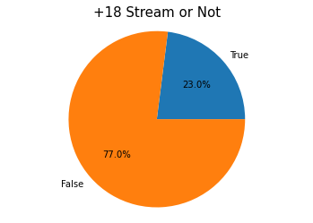

```
Number of Streamers who have mature content: 230
Number of Streamers who do not have mature content: 770
```

```python
# mature content's impact on overall popularity
notMature = 0
isMature = 0

for i, row in streamers.iterrows():
    if row['Mature'] == True:
        isMature += 1
    elif row['Mature'] == False:
        notMature += 1

labels = ['True','False']
sizes = [int(isMature),int(notMature)]

fig, ax = plt.subplots()
ax.pie(sizes, labels=labels, autopct='%1.1f%%')
# Equal aspect ratio ensures the pie chart is circular.
ax.axis('equal')
ax.set_title('+18 Stream or Not', fontsize='15')

plt.show()

print("Number of Streamers who have mature content: " + str(isMature))
print("Number of Streamers who do not have mature content: " + str(notMature))
```

Of the top 1000 Twitch streamers in the given dataset, only 230 stream mature, +18, content. Initially, I thought that there would be more streamers that do +18 streams due to the commonly violent nature of many popular videogames. However, upon further analysis, we found that a majority of the top Twitch streamers actually stream content for all ages. This shows that by having certain content for a stream, there is a larger audience available to increase the viewers. Since this is indicative of the top 1000 Twitch streamers, we only get a very general analysis that overall, not having an age requirement may lead to more popularity.

In order to see a more specific impact of mature content, I plot a dataset of just the top 100 Twitch streamers to show that the same statistics among the most successful Twitch streamers.

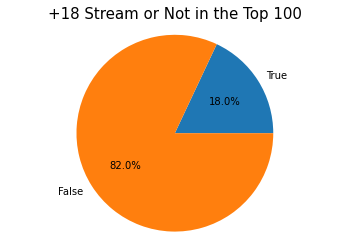

```
Number of Streamers who have mature content: 18
Number of Streamers who do not have mature content: 82
```

```python
# streamers100 contains top 100 Twitch streamers
streamers100 = streamers.head(100)

notMature = 0
isMature = 0

for i, row in streamers100.iterrows():

    if row['Mature'] == True:
        isMature += 1
    elif row['Mature'] == False:
        notMature += 1

labels = ['True','False']
sizes = [int(isMature),int(notMature)]

fig, ax = plt.subplots()
ax.pie(sizes, labels=labels, autopct='%1.1f%%')
# Equal aspect ratio ensures the pie chart is circular.
ax.axis('equal')
ax.set_title('+18 Stream or Not in the Top 100',fontsize='15')

plt.show()
print("Number of Streamers who have mature content: " + str(isMature))
print("Number of Streamers who do not have mature content: " + str(notMature))
```

After displaying the top 100 Twitch streamers and whether their stream content is +18, we see that similar to the last larger dataset, having an inclusive stream seems to be an advantage. If anything, there is now a smaller ratio of mature content once we get to the top 100 Twitch streamers. This makes more logical sense as not having age restrictions for a stream allows more accounts to watch the content. We can derive that there is a correlation between content/maturity and popularity as a Twitch streamer. This is useful information for novice streamers who want to grow and reach out to more viewers and can then tailor their content to maximize viewership.

Next we are going to explore the relationship between the top streamers and whether their accounts are partnered with Twitch.

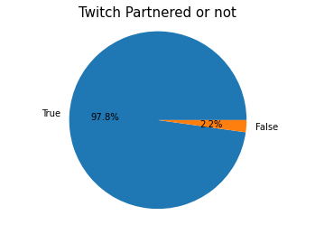

```
Number of Streamers who are Twitch Partnered: 978
Number of Streamers who are not Twitch Partnered: 22
```

```python
# Twitch Partnered or not
notPartnered = 0
isPartnered = 0

for i, row in streamers.iterrows():
    if row['Partnered'] == True:
        isPartnered += 1
    elif row['Partnered'] == False:
        notPartnered += 1

labels = ['True','False']
sizes = [int(isPartnered),int(notPartnered)]

fig, ax = plt.subplots()
ax.pie(sizes, labels=labels, autopct='%1.1f%%')
# Equal aspect ratio ensures the pie chart is circular.
ax.axis('equal')
ax.set_title('Twitch Partnered or not', fontsize='15')

plt.show()

print("Number of Streamers who are Twitch Partnered: " + str(isPartnered))
print("Number of Streamers who are not Twitch Partnered: " + str(notPartnered))
```

The Twitch Partnership Program is for those who are committed to streaming and are ready to level up from Affiliate. Twitch Partners are creators who stream a variety of content and have access to many benefits. We see that there is a pattern among the top Twitch streamers and if they are partnered. With only 2.2% of the 1000 top Twitch streamers not being Twitch Partnered, it is safe to say that there is an advantage to being partnered. There is a common trend that a majority of top Twitch streamers are indeed partnered with Twitch which could mean that they are gaining views as a result of the benefits.

More on the Twitch Partnership Program can be found here: https://www.twitch.tv/p/partners/

Now, moving into relationships within the data, we are going to explore the growth of these top channels through in groups of 100 streamers to visualize any pattern as popularity and rank increase.

[figure not shown]

```python
# Creating a scatterplot of the ratio of gained views to gained followers for each channel
ratio = []
channel = []

# Calculating the ratio
for i, row in streamers.iterrows():
    div = round(int(row['Views gained'])/int(row['Followers gained']))
    ratio.append(div)
    channel.append(i+1)

# Pushing values into a dataframe
dfratio = pd.DataFrame({'rank': channel, 'ratio': ratio})

# Scatterplot
fig = plt.figure(figsize=(16,9))
x = channel
y = ratio

# Random color for display purposes
color = np.random.rand(3,)
for x, y in zip(range(len(label)), list(diff)):
    rgb = np.random.rand(3,)
    plt.bar(x, y, 1, color=[rgb])

plt.title("The Ratio of Gained Views to Gained Followers (per channel)", fontsize='15')
plt.xlabel('Channel Rank', fontweight='bold')
plt.ylabel('Ratio of Gained Views to Gained Followers (in Millions)', fontweight='bold')
```

Next, let's create a similar bar chart but this time comparing the number of followers minus the average number of viewers for the top 100 streamers to see the potential active viewers for each channel.

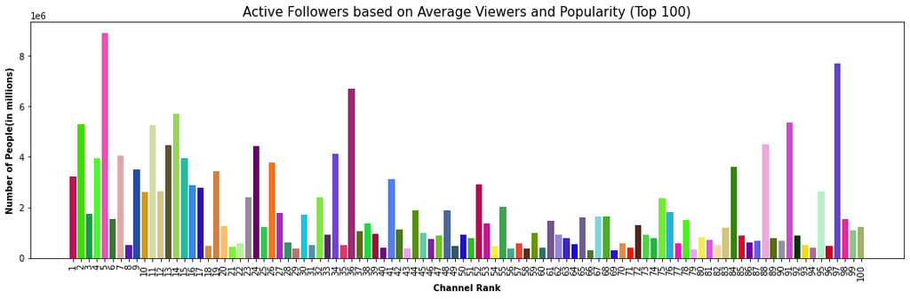

```python
# Average viewers - num of followers to see active viewers for top 100 streamers
diff = []
label = []

# Obtaining just the top 100 streamers
streamerTen = streamers.head(100)

for i, row in streamerTen.iterrows():
    difference = int(row['Followers']) - int(row['Average viewers'])
    diff.append(difference)
    label.append(i+1)

fig = plt.figure(figsize=(18,5))

# Random color for display purposes
color = np.random.rand(3,)
for x, y in zip(range(len(label)), list(diff)):
    rgb = np.random.rand(3,)
    plt.bar(x, y, color=[rgb])

plt.xlabel('Channel Rank', fontweight='bold')
plt.ylabel('Number of People(in millions)', fontweight='bold')
plt.title("Active Followers based on Average Viewers and Popularity (Top 100)", fontsize='15')
plt.xticks(range(len(diff)), list(label), rotation=90)

plt.show()
```

Here we see the top 100 Twitch streamers and the difference between the number of followers and average viewers. From just this bar graph, it is difficult to see a pattern in the number of average viewers and followers. This shows the importance of the size of a dataset, especially when trying to make a meaningful analysis on a certain topic. One could come to the conclusion that there is no correlation between those two things and the popularity of a channel. Originally, I hoped to be able to come to a conclusion that there was a relationship between the number of average viewers and the number of followers regarding active followers. In order to visualize this better, we will create a scatter plot of all 1000 streamers to create a more reliable visual with the original, larger dataset.

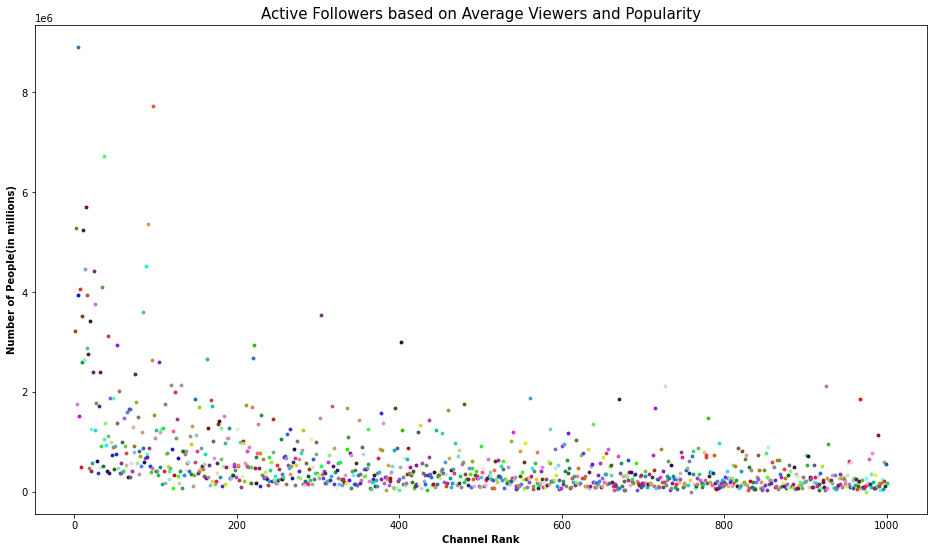

```python
# Creating a scatterplot of average viewers vs num of followers to see active viewers for top 1000 streamers
diff = []
label = []

# Calculating difference
for i, row in streamers.iterrows():
    difference = int(row['Followers']) - int(row['Average viewers'])
    diff.append(difference)
    label.append(i+1)

# Pushing values into a dataframe
dfdiff = pd.DataFrame({'label': label, 'difference': diff})

# Scatterplot
fig = plt.figure(figsize=(16,9))
x = dfdiff.label
y = dfdiff.difference

# Random color for display purposes
color = np.random.rand(3,)

for x, y in zip(x, y):
    rgb = np.random.rand(3,)
    plt.scatter(x, y, 8, c=[rgb])

plt.title("Active Followers based on Average Viewers and Popularity", fontsize='15')
plt.xlabel('Channel Rank', fontweight='bold')
plt.ylabel('Number of People(in millions)', fontweight='bold')
```

Using the scatterplot of all 1000 top Twitch streamers, we can now see some pattern among the difference of Average viewers and Followers for each respective Twitch streamer. At first glance, it seems that the data has a bit of a right skew as the difference between the number of Followers and the Average viewers decreases as the ranking of channels lowers. The most popular channels seem to have a large difference between the number of followers and viewers which shows that not all of their followers are always viewing each stream. Despite this, these channels are gaining views somehow, perhaps from an outside factor.

We did come to this conclusion assuming that the average number of viewers is made up of those that also follow the channel. One major factor to consider is that it is possible that not all of the viewers may be followers, so there may be some discrepancies with this as it was not specified in the dataset. In order to continue analyzing this data, we can utilize these plots to draw more conclusions with the help of linear regressions.

### Hypothesis Testing and Predicting with Machine Learning

```
[[-1192.0956248]] [1161916.88821021]
```

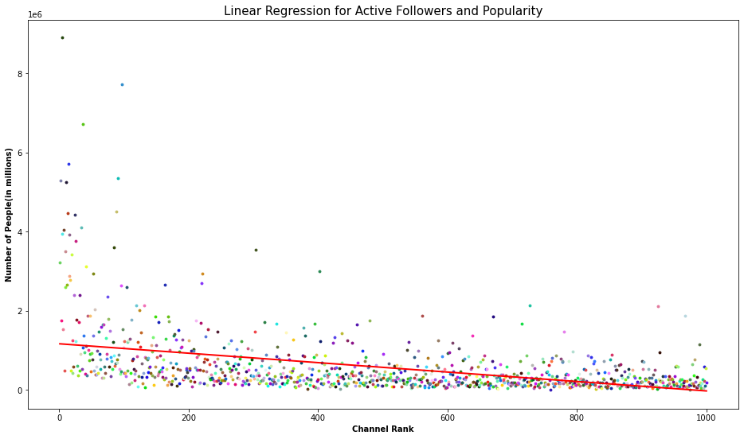

```python
# Scatterplot of average viewers vs num of followers
fig = plt.figure(figsize=(16,9))
x = dfdiff.label
y = dfdiff.difference

# Pushing values into a dataframe
dfdiff = pd.DataFrame({'label': label, 'difference': diff})

# Random color for display purposes
color = np.random.rand(3,)

for x, y in zip(x, y):
    rgb = np.random.rand(3,)
    plt.scatter(x, y,8, c=[rgb])

plt.title("Linear Regression for Active Followers and Popularity", fontsize='15')
plt.xlabel('Channel Rank', fontweight='bold')
plt.ylabel('Number of People(in millions)', fontweight='bold')

# NumPy's polyfit to ease interpretation
b, m = polyfit(label, diff, 1)
plt.plot(label, np.multiply(m, label) + b, '-', c='red', lw=2)


x = dfdiff['label'].values.reshape(-1,1)
y = dfdiff['difference'].values.reshape(-1,1)
reg = LinearRegression().fit(x, y)
coef = reg.coef_
intercept = reg.intercept_
print(coef, intercept)
```

The red line helps with the interpretation and represents the regression line of the difference between the number of Followers and Average viewers for each streamer from most popular to least. Based off of the regression line, the top streamers experience a large difference between the average number of viewers and the number of followers while those less popular tend have less of a difference. This difference from the top most streamers to less popular streamers shows that with popularity comes with a gap between viewers and viewers who follow the channel. The regression shows that more popular channels are more likely to have a larger gap between followers and viewers on average. This means that as a channel becomes more popular, less followers will regularly watch all the content.

The slope supports this hypothesis as it decreases as we move to lower ranked channels. One thing to consider here is that this slope is not indicative of all the information presented to us. So, in order to continue with our hypothesis testing, we need to find the linear regression with information in other columns to find an interation term between popularity and other factors.

More information on linear regression can be found here: https://scipy-lectures.org/packages/scikit-learn/auto_examples/plot_linear_regression.html

```
[[-0.01896801]] [53.1331387]
```

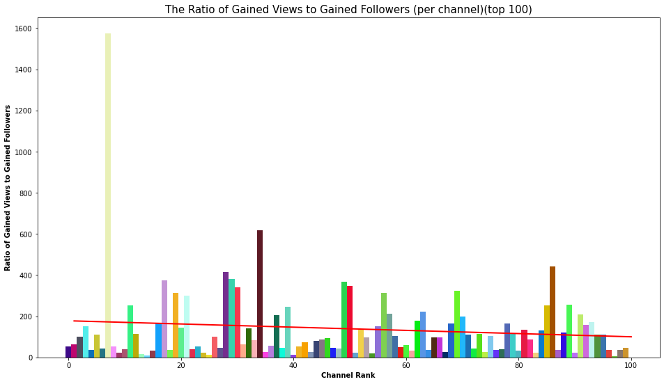

```python
# The ratio of gained views to gained followers for each channel
ratio = []
channel = []

# Calculating the ratio
for i, row in streamerTen.iterrows():
    div = round(int(row['Views gained'])/int(row['Followers gained']))
    ratio.append(div)
    channel.append(i+1)

# Scatterplot
fig = plt.figure(figsize=(16,9))
x = channel
y = ratio

# Pushing values into a dataframe
dfratio = pd.DataFrame({'ratio': ratio, 'channel': channel})

# Random color for display purposes
color = np.random.rand(3,)

for x, y in zip(range(len(x)), y):
    rgb = np.random.rand(3,)
    plt.bar(x, y, 1, color=[rgb])

plt.title("The Ratio of Gained Views to Gained Followers (per channel)(top 100)", fontsize='15')
plt.xlabel('Channel Rank', fontweight='bold')
plt.ylabel('Ratio of Gained Views to Gained Followers', fontweight='bold')

# NumPy's polyfit to ease interpretation
b, m = polyfit(channel, ratio, 1)
plt.plot(channel, np.multiply(m, channel) + b, '-', c='red', lw=2)

x = dfratio['ratio'].values.reshape(-1,1)
y = dfratio['channel'].values.reshape(-1,1)
reg = LinearRegression().fit(x, y)
coef = reg.coef_
intercept = reg.intercept_
print(coef, intercept)
```

As I mentioned earlier on in the Exploratory Data Analysis, there is a relationship between the amount of gained followers based on the gained views for each channel. The regression line above has a less drastic slope but we are also looking at only 100 top streamers which greatly limits our conclusion that for most of the top Twitch streamers, the amount of gained follows requires more views the more popular one's channel is.

To gain more insight and to see the importance of a large dataset, we will now display the same thing but with the full dataset.

```
[[0.14833715]] [123.29925526]
```

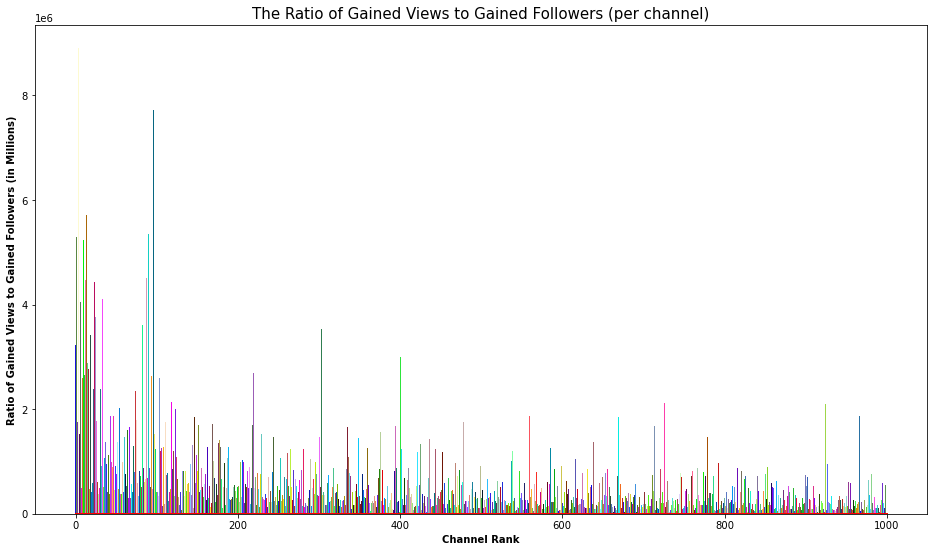

```python
# Creating a scatterplot of the ratio of gained views to gained followers for each channel
ratio = []
channel = []

# Calculating the ratio
for i, row in streamers.iterrows():
    div = round(int(row['Views gained'])/int(row['Followers gained']))
    ratio.append(div)
    channel.append(i+1)

# Pushing values into a dataframe
dfratio = pd.DataFrame({'rank': channel, 'ratio': ratio})

# Scatterplot
fig = plt.figure(figsize=(16,9))
x = channel
y = ratio

# Random color for display purposes
color = np.random.rand(3,)
for x, y in zip(range(len(label)), list(diff)):
    rgb = np.random.rand(3,)
    plt.bar(x, y, 1, color=[rgb])

plt.title("The Ratio of Gained Views to Gained Followers (per channel)", fontsize='15')
plt.xlabel('Channel Rank', fontweight='bold')
plt.ylabel('Ratio of Gained Views to Gained Followers (in Millions)', fontweight='bold')

# NumPy's polyfit to ease interpretation
b, m = polyfit(channel, ratio, 1)
plt.plot(channel, np.multiply(m, channel) + b, '-', c='red', lw=2)

x = dfratio['rank'].values.reshape(-1,1)
y = dfratio['ratio'].values.reshape(-1,1)
reg = LinearRegression().fit(x, y)
coef = reg.coef_
intercept = reg.intercept_
print(coef, intercept)
```

The next step is now to make predictions regarding our dataset, specifically with the growth pattern of the top Twitch streamers. We have a general idea of what factors play into a successful streamer and now we are going to make predictions based off of our linear regressions above.

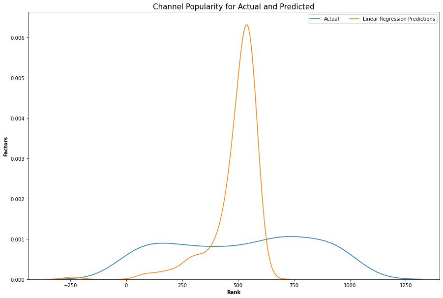

```python
Ranks = list(range(1000))

# Popularity factors
# Create dataframe to hold what factors impact popularity based on earlier linear regressions
factors = pd.DataFrame({'Channel':streamers['Channel'], 'Rank':Ranks, 'Mature':streamers['Mature'], 'Partnered':streamers['Partnered'],\
                       'Active Followers':dfdiff['difference'],'Growth Rate': dfratio['ratio']})

X = factors[['Active Followers','Growth Rate']]
Y = factors['Rank']

x_train, x_test,y_train,y_test = train_test_split(X,Y,test_size =0.2)

clf = LinearRegression()

# Fit the data
clf.fit(x_train,y_train)

# Predict using x_test
pred = clf.predict(x_test)

# Plot how the predicted popularity compares to our current data
f, ax = plt.subplots(figsize=(15,10))
plt.title('Channel Popularity for Actual and Predicted', fontsize ='15')
plt.xlabel("Rank", weight='bold')
plt.ylabel("Factors", weight='bold')
sns.distplot(y_test, hist=False, label="Actual", ax=ax)
sns.distplot(pred, hist=False, label="Linear Regression Predictions", ax=ax)
plt.legend(ncol=7)

plt.show()
```

More on Linear Regressions and Split Datasets Using Sklearn can be found here: https://medium.com/the-code-monster/split-a-dataset-into-train-and-test-datasets-using-sk-learn-acc7fd1802e0

### Conclusion

A key function of using data science with this top Twitch streamer dataset is using behavioral data to build data and see how people discover and move between streams and channels. By looking at the data from the top Twitch streamers, we gain more insight on how their audience reacted to streamers of varying popularity.

With the use of the plots and linear regression lines, we now know which factors have an impact on popularity and ranking of a Twitch channel. Among the top 1000 Twitch streamers, common factors included:

- Content for all ages (Mature)
- Twitch Partners
- An significant amount of active followers
- A constant growth rate of new viewers and followers

Based on these trends we can say that it is easy to start growth quickly but it gets competitive as the channel gets more popular. This is reasonable since a smaller channel is able to be more personal to each follower but as they grow, it is harder to maintain a personal connection to each account. Growing popular also means more content which not every follower will view which impacted our findings in the Active Follower plot with regression.

As I approached the EDA, I wanted to easily visualize any patterns in the dataset among the top Twitch streamers. The clearest method was using a pie chart to find very common patterns among the channels especially when it came to mature content and whether a channel is a partner. As we progressed through the Exploratory Data Analysis, bar charts and scatter plots made more sense for the large amount of data at hand. In analyzing the EDA portion of our project several conclusions can be made based on the factors that correlate to the reason why certain streamers are more popular than others.

Putting in the effort during the EDA allows us to answer important questions on the success of certain streamers and helps other streamers improve their following and views. Like any data analysis, we were able to answer a few questions but also derive more for further analysis. Moving forward, developing a new model on specific streamers given the chronology of their growth in popularity would shed more light on habits that top Twitch streamers do to be successful. While gathering this data, we would need to consider the up and coming streamers and predict those channels growing in popularity. The possibilities are endless when it comes to this and any dataset.

Overall, the trends of the top Twitch streamers can reflect other factors in the world. The increase of viewers shows that people are spending more time indoors or at least in front of an electronic device. The world is constantly changing and with that comes a constant flow of data.

An interesting article on online gaming and the pandemic for those interested: https://www.bbc.com/worklife/article/20201215-how-online-gaming-has-become-a-social-lifeline